# Cafe du mRcredi 01

LEM Zeppelin ;)

# Intro

L’idée pour cette partie est d’apprendre à utiliser des packages récemment développés dans l’univR, qui permettent de gagner beaucoup de temps par rapport aux commandes de base de R. On verra également certains trucs cool présents dans RStudio qui permettent d’être plus efficace en développant du code R.

Pour apprendre à utiliser les packages en question, on va partir d’un jeu de donnée présent dans le package `babynames`. Il contient un tableau d’1.8M de lignes, qui nous permettront d’utiliser plusieurs commandes sur un jeu de donnée simple mais pas anodin.

Avant tout ça, il faut déjà pouvoir les installer.

# Installation des packages

R n’est rien sans ses extensions. Récemment, un groupe de développeur a mis au point un système de packages aux fonctions claires, aux comportements cohérents, qui s’assemblent bien les uns avec les autres.

Pour commencer, il faut qu’on installe ces packages.

> Installation de `babynames` :

Avec la dernière version de R (3.3.2 au 2017-01-04), vous pouvez utiliser :

```r
## install.packages(babynames)
##
## (je met un signe commentaire ## pour que R n'exécute pas la commande alors que
## j'ai déjà le package installé.)
```

Si vous avez une version plus ancienne, soit mettez-là à jour, soit utiliser la commande suivante :

```r
## install.packages("devtools")
```

`devtools` est un package qui permet de se faciliter la vie quand on développe des packages dans R. Entre autre, il permet de télécharger des packages directement depuis le serveur de développement GitHub. Ce qu’on peut faire pour installer le package `babynames` avec la commande suivante :

```r
## devtools::install_github("hadley/babynames")
```

Pour résumer, soit le package est déjà présent sur le CRAN (l’archive de dépôt des packages R) et on peut l’installer avec `install.packages`, soit il est présent uniquement sur le serveur de développement, et on peut sans doute l’installer avec `devtools::install_github`.

> Installation de `tidyverse` :

Le package tidyverse permet d’appeler les packages qui vont nous intéresser au café du mRcredi. On l’installe donc comme ça :

```r
## install.packages("tidyverse")
```

# Chargement des packages

Une fois que les packages sont installés, il faut les charger dans la session.

On utilise donc la commande `library`.

(NB: il est possible d’utiliser une fonction depuis un package sans avoir à le charger dans la session avec la syntaxe `package::fonction_du_package()`, comme pour `devtools::install_github()`)

```r
library(babynames)
library(tidyverse)
```

Normalement quand on charge le package tidyverse, on voit des messages qui indique que les packages `ggplot2`, `tidyr` et consorts ont été chargés dans la session.

L’idée pour cette session c’est d’arriver à comprendre le code suivant, qui produit le graphique suivant :

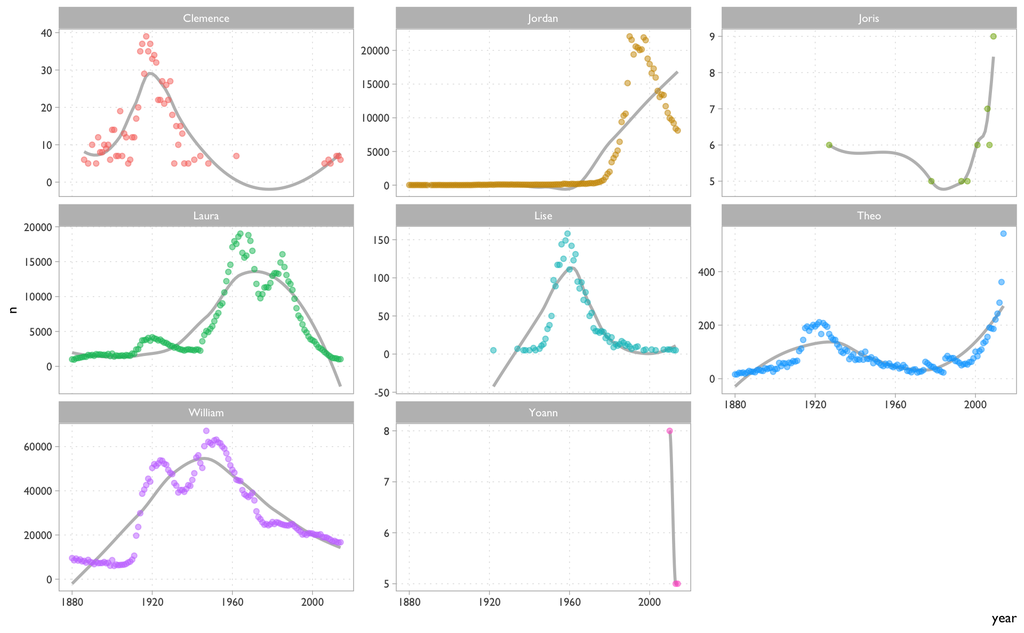

```r
participants <-
  c("Laura", "Jordan", "Theo", "Lise", "Yoann", "William", "Joris", "Clemence")

babynames %>%
  filter(name %in% participants) %>%
  group_by(name, year) %>%
  summarise(n = sum(n)) %>%
  ggplot(aes(x = year, y = n)) +
  geom_smooth(se = FALSE, color = "gray") +
  geom_point(aes(color = name), alpha = 1/2) +
  facet_wrap(~name, scales = "free_y") +
  guides(color = "none")
```

# Babynames

Jettons d’abord un coup d’œil aux données, c’est quand même la base d’une analyse.

```r
babynames
```

```
## # A tibble: 1,825,433 x 5
##     year   sex      name     n       prop
##    <dbl> <chr>     <chr> <int>      <dbl>
## 1   1880     F      Mary  7065 0.07238359
## 2   1880     F      Anna  2604 0.02667896
## 3   1880     F      Emma  2003 0.02052149
## 4   1880     F Elizabeth  1939 0.01986579
## 5   1880     F    Minnie  1746 0.01788843
## 6   1880     F  Margaret  1578 0.01616720
## 7   1880     F       Ida  1472 0.01508119
## 8   1880     F     Alice  1414 0.01448696
## 9   1880     F    Bertha  1320 0.01352390
## 10  1880     F     Sarah  1288 0.01319605
## # ... with 1,825,423 more rows
```

Il y a donc cinq colonnes, qui correspondent à l’année, au sexe, au prénom, au nombre d’enfants du sexe donné qui ont été baptisés ainsi au cours de l’année, et la proportion des enfants baptisés par ce nom pour cet année et pour ce sexe.

# dplyr::filter

La première fonction qui va nous intéresser est la fonction `filter`. Elle permet de filtrer des *lignes* en fonction de conditions qui nous intéressent.

Par exemple, pour ne garder que les lignes où la colonne `n` prend une valeur supérieure à 10000 :

```r
filter(.data = babynames, n > 1e4)
```

```
## # A tibble: 5,730 x 5
##     year   sex  name     n       prop
##    <dbl> <chr> <chr> <int>      <dbl>
## 1   1888     F  Mary 11754 0.06204276
## 2   1889     F  Mary 11648 0.06155830
## 3   1890     F  Mary 12078 0.05989230
## 4   1891     F  Mary 11703 0.05953695
## 5   1892     F  Mary 13173 0.05856749
## 6   1893     F  Mary 12784 0.05675900
## 7   1894     F  Mary 13151 0.05573119
## 8   1895     F  Mary 13446 0.05441323
## 9   1896     F  Mary 13811 0.05480664
## 10  1897     F  Mary 13413 0.05402434
## # ... with 5,720 more rows
```

Pour ne garder que les lignes où la colonne `name` prend la valeur `"Laura"` :

```r
filter(.data = babynames, name == "Laura")
```

```
## # A tibble: 246 x 5
##     year   sex  name     n         prop
##    <dbl> <chr> <chr> <int>        <dbl>
## 1   1880     F Laura  1012 1.036832e-02
## 2   1881     F Laura   962 9.731326e-03
## 3   1882     F Laura  1151 9.948314e-03
## 4   1882     M Laura     5 4.097252e-05
## 5   1883     F Laura  1183 9.853078e-03
## 6   1884     F Laura  1246 9.056022e-03
## 7   1885     F Laura  1325 9.334273e-03
## 8   1886     F Laura  1372 8.924274e-03
## 9   1886     M Laura     5 4.200234e-05
## 10  1887     F Laura  1364 8.776050e-03
## # ... with 236 more rows
```

Pour ne garder que les lignes où la colonne `name` prend la valeur `"Laura"` et où le sexe est féminin :

```r
filter(babynames, name == "Laura", sex == "F")
```

```
## # A tibble: 135 x 5
##     year   sex  name     n        prop
##    <dbl> <chr> <chr> <int>       <dbl>
## 1   1880     F Laura  1012 0.010368321
## 2   1881     F Laura   962 0.009731326
## 3   1882     F Laura  1151 0.009948314
## 4   1883     F Laura  1183 0.009853078
## 5   1884     F Laura  1246 0.009056022
## 6   1885     F Laura  1325 0.009334273
## 7   1886     F Laura  1372 0.008924274
## 8   1887     F Laura  1364 0.008776050
## 9   1888     F Laura  1624 0.008572183
## 10  1889     F Laura  1567 0.008281409
## # ... with 125 more rows
```

(NB: on peut supprimer la mention `.data =`, par défaut toutes les fonctions de `dplyr` attendent en premier argument un jeu de donnée — une propriété bien utilisée ensuite.)

**Pour résumer**, la commande `filter` attend un jeu de donnée en premier argument, et des conditions de filtrations pour les différentes colonnes, séparées par des virgules, permettent de ne garder du jeu de donnée initial que les lignes qui nous intéressent.

# dplyr::mutate

La seconde fonction bien utile du package est la fonction `mutate`. Elle permet de changer la valeur de colonnes existantes, ou d’en créer de nouvelles. Bien utile quand on veut changer l’unité d’une colonne, ou calculer la différence entre deux valeurs présentes dans deux colonnes différentes. Exemples :

```r
## la fonction tibble permet de créer rapidement une table :
(df = tibble(a = c(1, 2, 3), b = c(3, 2, 1)))
```

```
## # A tibble: 3 x 2
##       a     b
##   <dbl> <dbl>
## 1     1     3
## 2     2     2
## 3     3     1
```

```r
mutate(.data = df, sum = a + b)
```

```
## # A tibble: 3 x 3
##       a     b   sum
##   <dbl> <dbl> <dbl>
## 1     1     3     4
## 2     2     2     4
## 3     3     1     4
```

Encore une fois on peut supprimer la mention `.data =` :

```r
mutate(df, diff = a - b)
```

```
## # A tibble: 3 x 3
##       a     b  diff
##   <dbl> <dbl> <dbl>
## 1     1     3    -2
## 2     2     2     0
## 3     3     1     2
```

```r
mutate(df, paste = paste0(a, b))
```

```
## # A tibble: 3 x 3
##       a     b paste
##   <dbl> <dbl> <chr>
## 1     1     3    13
## 2     2     2    22
## 3     3     1    31
```

On vient d’utiliser la fonction `mutate` trois fois pour créer une nouvelle colonne. On peut aussi changer une colonne existante :

```r
mutate(df, a = 2)
```

```
## # A tibble: 3 x 2
##       a     b
##   <dbl> <dbl>
## 1     2     3
## 2     2     2
## 3     2     1
```

Change toutes les valeurs de la colonne `name` en `"Laura"` :

```r
mutate(babynames, name = "Laura")
```

```
## # A tibble: 1,825,433 x 5
##     year   sex  name     n       prop
##    <dbl> <chr> <chr> <int>      <dbl>
## 1   1880     F Laura  7065 0.07238359
## 2   1880     F Laura  2604 0.02667896
## 3   1880     F Laura  2003 0.02052149
## 4   1880     F Laura  1939 0.01986579
## 5   1880     F Laura  1746 0.01788843
## 6   1880     F Laura  1578 0.01616720
## 7   1880     F Laura  1472 0.01508119
## 8   1880     F Laura  1414 0.01448696
## 9   1880     F Laura  1320 0.01352390
## 10  1880     F Laura  1288 0.01319605
## # ... with 1,825,423 more rows
```

Pas très utile, mais beaucoup plus quand on peut faire des choses comme ça :

```r
mutate(babynames, name = ifelse(sex == "F", "Jeanne", "Jean"))
```

```
## # A tibble: 1,825,433 x 5
##     year   sex   name     n       prop
##    <dbl> <chr>  <chr> <int>      <dbl>
## 1   1880     F Jeanne  7065 0.07238359
## 2   1880     F Jeanne  2604 0.02667896
## 3   1880     F Jeanne  2003 0.02052149
## 4   1880     F Jeanne  1939 0.01986579
## 5   1880     F Jeanne  1746 0.01788843
## 6   1880     F Jeanne  1578 0.01616720
## 7   1880     F Jeanne  1472 0.01508119
## 8   1880     F Jeanne  1414 0.01448696
## 9   1880     F Jeanne  1320 0.01352390
## 10  1880     F Jeanne  1288 0.01319605
## # ... with 1,825,423 more rows
```

Autrement dit en français, la colonne `name` prend la valeur “Jeanne” si la colonne `sex` est égale à “F”, “Jean” autrement.

> Peut-être que vous l’avez noté mais les commandes se font très rapidement sur un gros jeu de donnée, c’est aussi l’intérêt du package dplyr (les fonctions sont codées en C++, un language de programmation très performant).

> L’autre gros intérêt est que le jeu de donnée initial n’est jamais modifié. `babynames` garde les mêmes valeurs. Donc on ne craint pas de perdre des données en rentrant une mauvaise commande.

# dplyr::group_by & dplyr::summarise

Souvent en analyse de données, on a besoin d’effectuer des commandes sur des groupes de données. Par exemple, pour chaque plante dans la colonne “plante”, calcule la longueur moyenne de racine. On peut donc grouper les données par valeur dans une colonne.

Ça se fait avec la fonction `group_by` et sa copine `summarise`.

```r
group_by(babynames, name)
```

```
## Source: local data frame [1,825,433 x 5]
## Groups: name [93,889]
##
##     year   sex      name     n       prop
##    <dbl> <chr>     <chr> <int>      <dbl>
## 1   1880     F      Mary  7065 0.07238359
## 2   1880     F      Anna  2604 0.02667896
## 3   1880     F      Emma  2003 0.02052149
## 4   1880     F Elizabeth  1939 0.01986579
## 5   1880     F    Minnie  1746 0.01788843
## 6   1880     F  Margaret  1578 0.01616720
## 7   1880     F       Ida  1472 0.01508119
## 8   1880     F     Alice  1414 0.01448696
## 9   1880     F    Bertha  1320 0.01352390
## 10  1880     F     Sarah  1288 0.01319605
## # ... with 1,825,423 more rows
```

Il ne se passe rien, sinon que le jeu de donnée est découpé en environ 90000 groupes, correspondants aux 90000 noms différents dans le jeu de donnée.

Maintenant, si on utilise la fonction summarise (ou summarize, c’est au choix) sur ce jeu découpé en groupes :

```r
summarise(group_by(babynames, name), sum_par_prenom = sum(n))
```

```
## # A tibble: 93,889 x 2
##         name sum_par_prenom
##        <chr>          <int>
## 1      Aaban             72
## 2      Aabha             21
## 3      Aabid              5
## 4  Aabriella             10
## 5      Aadam            196
## 6      Aadan            112
## 7    Aadarsh            158
## 8      Aaden           3920
## 9     Aadesh             15
## 10    Aadhav            102
## # ... with 93,879 more rows
```

Notez qu’il ne peut pas y avoir d’espace dans les noms de colonne, donc on utilise le `_`, l’un des seuls symbole neutre qui n’ait pas de valeur dans R.

En français, la commande précédente veut dire : par nom, calcule la somme des n, autrement dit compte le nombre d’invididus portant un nom donné dans le dataset.

Peut-être que vous avez vu qu’on pouvait enchâsser des fonctions les unes dans les autres. (C’est une particularité des languages dits fonctionnels, dont R fait partie). Par exemple dans la commande précédente, l’argument `.data =` prenait la valeur renvoyée par l’application de la fonction `group_by(babynames, name)`.

```r
summarise(group_by(babynames, year), individus_comptes_par_annee = sum(n))
```

```
## # A tibble: 135 x 2
##     year individus_comptes_par_annee
##    <dbl>                       <int>
## 1   1880                      201484
## 2   1881                      192699
## 3   1882                      221538
## 4   1883                      216950
## 5   1884                      243467
## 6   1885                      240855
## 7   1886                      255319
## 8   1887                      247396
## 9   1888                      299480
## 10  1889                      288950
## # ... with 125 more rows
```

En français, compte le nombre d’individus recensés par année.

Souvent, on veut compter le nombre de lignes dans un groupe. On peut utiliser la fonction `n()`. Exemple :

```r
summarise(group_by(babynames, year), prenoms_different_par_annee = n())
```

```
## # A tibble: 135 x 2
##     year prenoms_different_par_annee
##    <dbl>                       <int>
## 1   1880                        2000
## 2   1881                        1935
## 3   1882                        2127
## 4   1883                        2084
## 5   1884                        2297
## 6   1885                        2294
## 7   1886                        2392
## 8   1887                        2373
## 9   1888                        2651
## 10  1889                        2590
## # ... with 125 more rows
```

Autrement dit, compte le nombre de prénoms différents par année.

À ce moment, on aurait envie de faire des petits graphiques pour voir s’il n’y aurait pas une tendance quelconque dans les analyses qu’on fait.

Juste avant, il faut parler de l’opérateur `%>%`, un peu spécial à prendre en main mais très puissant.

# dplyr::`%>%`

Le but de cet opérateur est d’aider à écrire du code qui est plus clean.

Il existe des alternatives qu’on trouve fréquemment dans R. Pour ça on va utiliser ce petit exemple tout pourri, adapté d’un poème pour enfant avec un peu de grand n’importe quoi.

> Le petit lapin foofoo Cours à travers la forêt Attrape les souris Et leur écrase la tête.

Si on veut raconter l’histoire du petit lapin `foo_foo` avec les trois principales actions `cours()`, `attrape()` et `ecrase()` dans R, on peut :

1. Sauver chaque étape dans un nouvel objet.
2. Écraser l’objet original et remplacer par un nouveau.
3. Enchâsser les fonctions.
4. Utiliser l’opérateur `%>%`.

Si on décide de sauver chaque étape du processus dans un nouvel objet :

```r
foo_foo <- petit_lapin()
foo_foo_1 <- cours(qui = foo_foo, a_travers = la_foret)
foo_foo_2 <- attrape(qui = foo_foo_1, quoi = les_souris)
foo_foo_3 <- ecrase(qui = foo_foo_2, quel_organe = leur_tete)
```

L’inconvénient, c’est qu’on est obligé d’écrire chaque élément intermédiaire. C’est nul parce qu’on perd en mémoire dès lors que le jeu de donnée est conséquent ; on pollue la session avec beaucoup de noms de variables ; on s’y perd ; c’est très dur de nommer des variables de façon cohérente et efficace …

On peut donc décider de remplacer chaque étape du processus par le nouveau résultat :

```r
foo_foo <- petit_lapin()
foo_foo <-   cours(qui = foo_foo, a_travers = la_foret)
foo_foo <- attrape(qui = foo_foo, quoi = les_souris)
foo_foo <-  ecrase(qui = foo_foo, quel_organe = leur_tete)
```

L’inconvénient c’est qu’on ne sait jamais quel étape du processus ne marche pas, quand ça ne marche pas, et qu’on ne sait jamais bien à quel étape du processus on se situe quand ces commandes sont éloignées les unes des autres dans le script.

On peut alors décider d’enchâsser les fonctions :

```r
foo_foo <- petit_lapin()
ecrase(qui = attrape(qui = cours(qui = foo_foo,
                                 a_travers = la_foret),
                     quoi = les_souris),
       quel_organe = leur_tete)
```

L’inconvénient c’est qu’on doit lire depuis l’intérieur, de la droite vers la gauche, et que les arguments sont loins les uns des autres.

On peut donc utiliser l’opérateur `%>%` !

```r
foo_foo %>%
  cours(a_travers = la_foret) %>%
  attrape(quoi = les_souris) %>%
  ecrase(quel_organe = leur_tete)
```

Si on revient à nos exemples dans le monde pseudo-réel :

On peut remplacer :

```r
summarise(group_by(babynames, year), count = n())
```

```
## # A tibble: 135 x 2
##     year count
##    <dbl> <int>
## 1   1880  2000
## 2   1881  1935
## 3   1882  2127
## 4   1883  2084
## 5   1884  2297
## 6   1885  2294
## 7   1886  2392
## 8   1887  2373
## 9   1888  2651
## 10  1889  2590
## # ... with 125 more rows
```

Par :

```r
babynames %>%
  group_by(year) %>%
  summarise(count = n())
```

```
## # A tibble: 135 x 2
##     year count
##    <dbl> <int>
## 1   1880  2000
## 2   1881  1935
## 3   1882  2127
## 4   1883  2084
## 5   1884  2297
## 6   1885  2294
## 7   1886  2392
## 8   1887  2373
## 9   1888  2651
## 10  1889  2590
## # ... with 125 more rows
```

L’opérateur `%>%` permet de remplacer le premier argument de la fonction suivante par la valeur renvoyée par la fonction précédente.

Dans `dplyr`, toutes les fonctions acceptent pour premier argument l’argument `.data`, ce qui nous permet facilement de mettre les fonctions les unes à la suite des autres.

# Premiers graphiques !

On en était il y a quelque temps à se dire qu’on ferait bien quelques graphiques sur nos données manipulées.

Exemple :

```r
babynames %>%
  group_by(year) %>%
  summarise(count = n())
```

```
## # A tibble: 135 x 2
##     year count
##    <dbl> <int>
## 1   1880  2000
## 2   1881  1935
## 3   1882  2127
## 4   1883  2084
## 5   1884  2297
## 6   1885  2294
## 7   1886  2392
## 8   1887  2373
## 9   1888  2651
## 10  1889  2590
## # ... with 125 more rows
```

Comment covarient le nombre prénoms différents avec l’année ? Notre hypothèse c’est que plus le temps passe, plus il y a de prénoms différents représentés dans le jeu de donnée (a priori il n’y avait que très peu de Titouan et autre Eleona en 1880, surtout aux USA.)

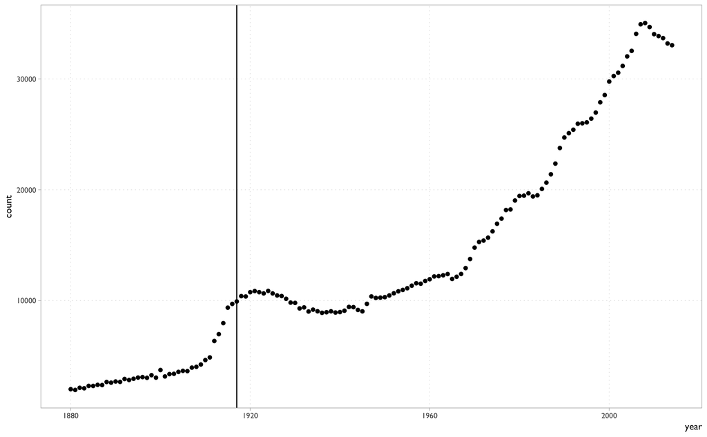

```r
babynames %>%
  group_by(year) %>%
  summarise(count = n()) %>%
  ggplot(aes(x = year, y = count)) +
  geom_point() +
  geom_vline(xintercept = 1917)
```

C’est bien ce qu’on observe. La diminution de diversité notée autour des années 1920 est certainement due aux changements de politique d’immigration observés aux USA à ce moment là.

Si on revient à R, on a utilisé des fonctions du package `ggplot2`, un package qui implémente la grammaire des graphiques dans R.

Pour faire court, cette grammaire veut qu’on puisse attribuer des dimensions du jeu de données à des aspects `aes`thétiques visuellement représentés sur le graphe. Ce qui est fait dans la ligne `ggplot(aes(x = year, y = count))`, où j’attribue à la dimension ésthétique `x` la dimension du jeu de donnée `year`. Autrement dit, représente en `x` l’année, en `y` le nombre de prénoms différents.

La fonction `geom_point` indique qu’on veut représenter ces attributions esthétiques par des figures géométriques en forme de point. Si vous consultez l’aide du package [ici](http://docs.ggplot2.org/current/), vous constaterez qu’il existe toute une tripotée de représentations géométriques disponibles, toutes plus ou moins pertinentes selon le contexte.

La fonction `geom_vline` représente une ligne verticale, qui coupe l’axe des `x` en 1917.

> On verra le package ggplot2 plus en détail aux prochains cours.

# Conclusion

Si on combine tout ce qu’on a vu jusqu’à maintenant :

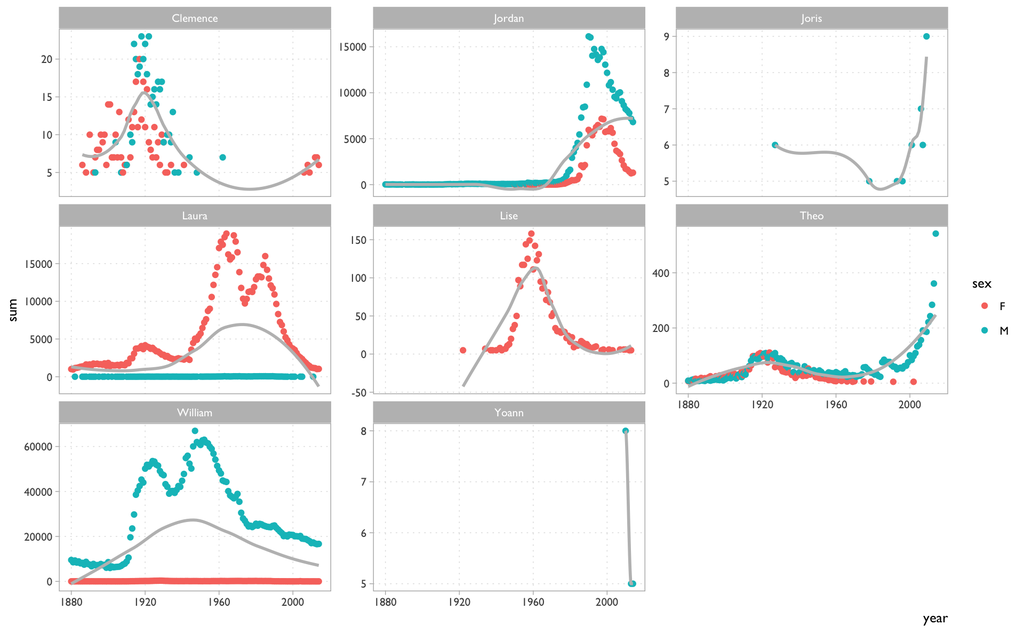

```r
## Ici on crée une liste des gens présents à l'atelier :
participants <-
  c("Laura", "Jordan", "Theo", "Lise", "Yoann", "William", "Joris", "Clemence")

babynames %>%
  # là on filtre pour ne garder que les lignes où le nom a une correspondance
  # dans le vecteur participants
  filter(name %in% participants) %>%
  # ensuite on groupe par année, par prénom et par sexe,
  group_by(year, name, sex) %>%
  # on fait la somme des cas comptés
  summarize(sum = sum(n)) %>%
  # on représente en x l'année, en y la somme des cas comptés et par la couleur
  # le sexe des individus comptés :
  ggplot(aes(x = year, y = sum, color = sex)) +
  # on veut représenter les attributions par une figure géométrique ponctuelle :
  geom_point() +
  # on peut ajouter une courbe de tendance de couleur grise, sans l'écart type (se)
  geom_smooth(se = FALSE, color = "gray") +
  # et on veut le même graphique pour tous les prénoms, donc on démultiplie par
  # petits panneaux (on veut un panneau par prénom). Comme les n varient
  # beaucoup par prénom, on ajuste l'échelle des y en fonction du n max par
  # panneau :
  facet_wrap( ~ name, scales = "free_y")
```